# project1

Introduction

The dataset includes historical NBA game data, with Elo ratings for each team before and after the games, the outcomes of the games, and various other metrics related to the performance of the teams. These data are used to analyze team performance over time, predict future game outcomes, and provide insights into the dynamics of the NBA league. For academic references, the Elo rating system was originally developed by Arpad Elo, a Hungarian-American physics professor and chess master. It has been widely adopted in many sports and games beyond chess, including basketball, where it helps to assess team strength and performance dynamics. Web: https://projects.fivethirtyeight.com/2023-nba-predictions/

```python
import warnings
warnings.simplefilter(action='ignore',category=FutureWarning)
warnings.simplefilter(action='ignore',category=DeprecationWarning)
import numpy as np
import pandas as pd
import matplotlib.pyplot as plt
import seaborn as sns
```

```python
projectdata=('nba_elo_latest.csv')
data=pd.read_csv(projectdata)
data.head()
```

|  | date | season | neutral | playoff | team1 | team2 | elo1_pre | elo2_pre | elo_prob1 | elo_prob2 | ... | carm-elo2_post | raptor1_pre | raptor2_pre | raptor_prob1 | raptor_prob2 | score1 | score2 | quality | importance | total_rating |
| --- | --- | --- | --- | --- | --- | --- | --- | --- | --- | --- | --- | --- | --- | --- | --- | --- | --- | --- | --- | --- | --- |
| 0 | 2022-10-18 | 2023 | 0 | NaN | BOS | PHI | 1657.639749 | 1582.247327 | 0.732950 | 0.267050 | ... | NaN | 1693.243079 | 1641.876729 | 0.670612 | 0.329388 | 126 | 117 | 96 | 13 | 55 |
| 1 | 2022-10-18 | 2023 | 0 | NaN | GSW | LAL | 1660.620307 | 1442.352444 | 0.862011 | 0.137989 | ... | NaN | 1615.718147 | 1472.173711 | 0.776502 | 0.223498 | 123 | 109 | 67 | 20 | 44 |
| 2 | 2022-10-19 | 2023 | 0 | NaN | IND | WAS | 1399.201934 | 1440.077372 | 0.584275 | 0.415725 | ... | NaN | 1462.352663 | 1472.018225 | 0.599510 | 0.400490 | 107 | 114 | 37 | 28 | 33 |
| 3 | 2022-10-19 | 2023 | 0 | NaN | DET | ORL | 1393.525172 | 1366.089249 | 0.675590 | 0.324410 | ... | NaN | 1308.969909 | 1349.865183 | 0.563270 | 0.436730 | 113 | 109 | 3 | 1 | 2 |
| 4 | 2022-10-19 | 2023 | 0 | NaN | ATL | HOU | 1535.408152 | 1351.164973 | 0.837022 | 0.162978 | ... | NaN | 1618.256817 | 1283.328356 | 0.917651 | 0.082349 | 117 | 107 | 24 | 1 | 13 |

5 rows × 27 columns

Preprocessing

In the preprocessing stage, we prepare the dataset for analysis by performing several key operations:

Type Conversions: Ensure that all data types are appropriate for the analysis. For instance, date columns should be converted to datetime format to facilitate time-based analysis. Removing Irrelevant Columns: Identify and discard columns that are not relevant to our analysis. This can include columns with excessive missing data or those that do not contribute meaningful information. Handling Missing Values: Detect and address missing data in the dataset. Depending on the nature and amount of missing data, we can either remove rows/columns with missing values or impute them based on statistical methods like mean, median, or mode. Outlier Analysis: Identify any outliers in the dataset. This step is crucial for understanding the data distribution and deciding whether any action needs to be taken regarding these outliers.

```python
data['date'] = pd.to_datetime(data['date'])

threshold = 0.5  # Threshold for removing columns with a high percentage of missing values
columns_to_remove = data.columns[data.isnull().mean() > threshold]
data_cleaned = data.drop(columns=columns_to_remove)
data_cleaned = data_cleaned.dropna()
# Descriptive statistics for quantitative columns
quantitative_columns = data_cleaned.select_dtypes(include=['number']).columns
outlier_analysis = data_cleaned[quantitative_columns].describe()
print(outlier_analysis)
```

```
       season      neutral     elo1_pre     elo2_pre    elo_prob1  \
count  1320.0  1320.000000  1320.000000  1320.000000  1320.000000
mean   2023.0     0.001515  1511.867655  1511.311315     0.627059
std       0.0     0.038910    88.962661    89.571409     0.151149
min    2023.0     0.000000  1264.103229  1257.300726     0.181341
25%    2023.0     0.000000  1461.568345  1460.866530     0.533438
50%    2023.0     0.000000  1524.876508  1523.136739     0.640681
75%    2023.0     0.000000  1576.453207  1577.825540     0.736876
max    2023.0     1.000000  1705.343075  1719.448667     0.933707

         elo_prob2    elo1_post    elo2_post  raptor1_pre  raptor2_pre  \
count  1320.000000  1320.000000  1320.000000  1320.000000  1320.000000
mean      0.372941  1510.664651  1512.514319  1503.864076  1499.075101
std       0.151149    89.560581    89.306155   116.590601   116.514412
min       0.066293  1257.300726  1271.086891   955.234235   945.804075
25%       0.263124  1460.990452  1460.476484  1445.292160  1432.346974
50%       0.359319  1521.917992  1525.368845  1523.778627  1522.906299
75%       0.466562  1576.753366  1577.663170  1585.715871  1579.358239
max       0.818659  1705.343075  1719.448667  1733.775148  1728.915073

       raptor_prob1  raptor_prob2       score1       score2      quality  \
count   1320.000000   1320.000000  1320.000000  1320.000000  1320.000000
mean       0.603891      0.396109   115.630303   113.030303    50.511364
std        0.187301      0.187301    11.991075    12.001920    27.217232
min        0.027498      0.017256    80.000000    79.000000     0.000000
25%        0.490977      0.257375   108.000000   105.000000    29.000000
50%        0.617850      0.382150   116.000000   113.000000    52.000000
75%        0.742625      0.509023   124.000000   121.000000    73.000000
max        0.982744      0.972502   175.000000   176.000000    99.000000

        importance  total_rating
count  1320.000000   1320.000000
mean     32.458333     41.744697
std      29.408726     24.238657
min       0.000000      0.000000
25%       9.000000     21.000000
50%      24.000000     43.500000
75%      49.000000     57.000000
max     100.000000    100.000000
```

Summary data analysis

In this section, we will conduct a comprehensive summary analysis of the dataset. This includes generating statistical summaries for each column to understand the central tendency, dispersion, and shape of the dataset's distribution. We will also use graphical components like histograms and box plots to visualize the data distribution of each column.

```
                                date  season      neutral     elo1_pre  \
count                           1320  1320.0  1320.000000  1320.000000
mean   2023-01-19 05:33:49.090909184  2023.0     0.001515  1511.867655
min              2022-10-18 00:00:00  2023.0     0.000000  1264.103229
25%              2022-12-02 00:00:00  2023.0     0.000000  1461.568345
50%              2023-01-16 00:00:00  2023.0     0.000000  1524.876508
75%              2023-03-08 00:00:00  2023.0     0.000000  1576.453207
max              2023-06-12 00:00:00  2023.0     1.000000  1705.343075
std                              NaN     0.0     0.038910    88.962661

          elo2_pre    elo_prob1    elo_prob2    elo1_post    elo2_post  \
count  1320.000000  1320.000000  1320.000000  1320.000000  1320.000000
mean   1511.311315     0.627059     0.372941  1510.664651  1512.514319
min    1257.300726     0.181341     0.066293  1257.300726  1271.086891
25%    1460.866530     0.533438     0.263124  1460.990452  1460.476484
50%    1523.136739     0.640681     0.359319  1521.917992  1525.368845
75%    1577.825540     0.736876     0.466562  1576.753366  1577.663170
max    1719.448667     0.933707     0.818659  1705.343075  1719.448667
std      89.571409     0.151149     0.151149    89.560581    89.306155

       raptor1_pre  raptor2_pre  raptor_prob1  raptor_prob2       score1  \
count  1320.000000  1320.000000   1320.000000   1320.000000  1320.000000
mean   1503.864076  1499.075101      0.603891      0.396109   115.630303
min     955.234235   945.804075      0.027498      0.017256    80.000000
25%    1445.292160  1432.346974      0.490977      0.257375   108.000000
50%    1523.778627  1522.906299      0.617850      0.382150   116.000000
75%    1585.715871  1579.358239      0.742625      0.509023   124.000000
max    1733.775148  1728.915073      0.982744      0.972502   175.000000
std     116.590601   116.514412      0.187301      0.187301    11.991075

            score2      quality   importance  total_rating
count  1320.000000  1320.000000  1320.000000   1320.000000
mean    113.030303    50.511364    32.458333     41.744697
min      79.000000     0.000000     0.000000      0.000000
25%     105.000000    29.000000     9.000000     21.000000
50%     113.000000    52.000000    24.000000     43.500000
75%     121.000000    73.000000    49.000000     57.000000
max     176.000000    99.000000   100.000000    100.000000
std      12.001920    27.217232    29.408726     24.238657
```

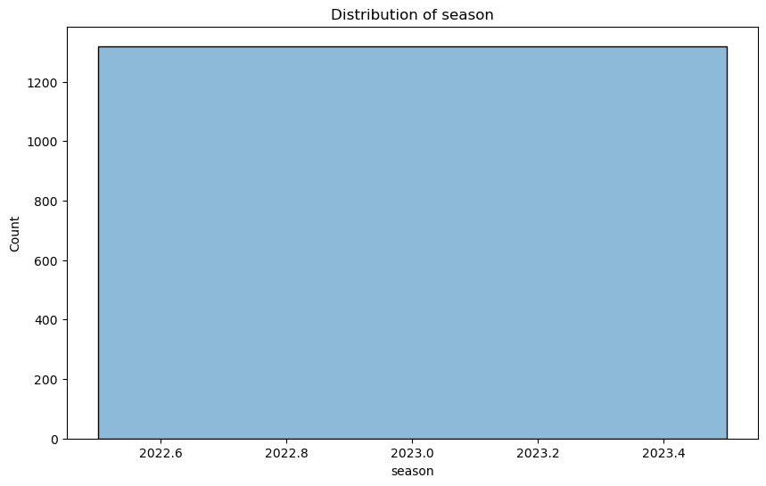

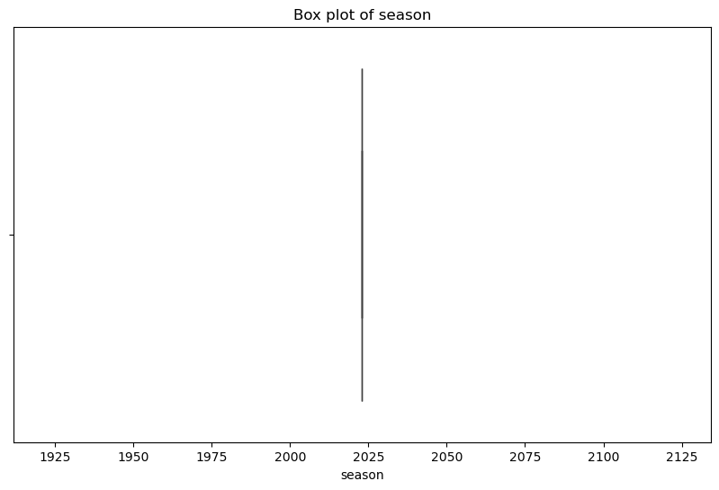

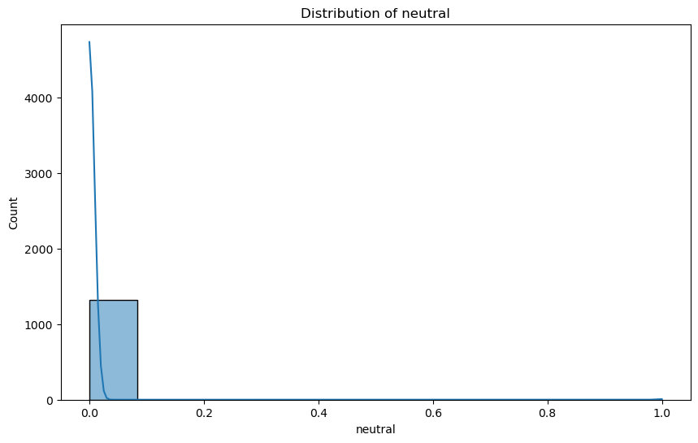

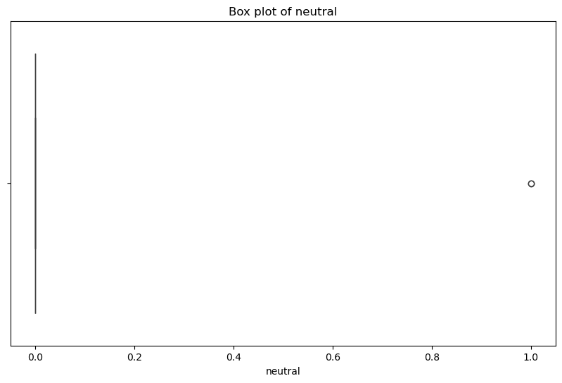

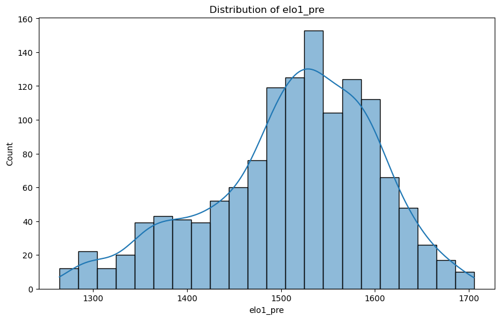

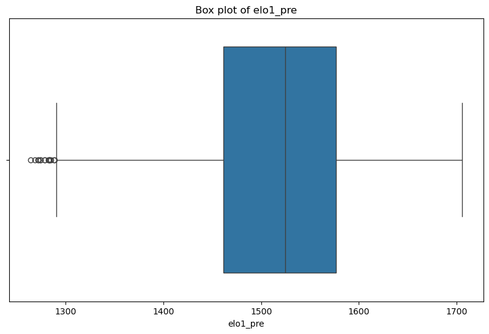

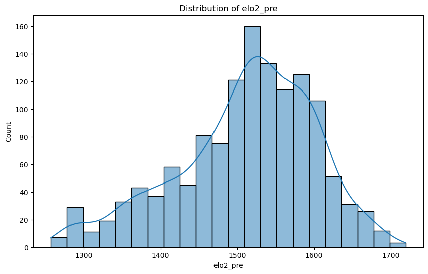

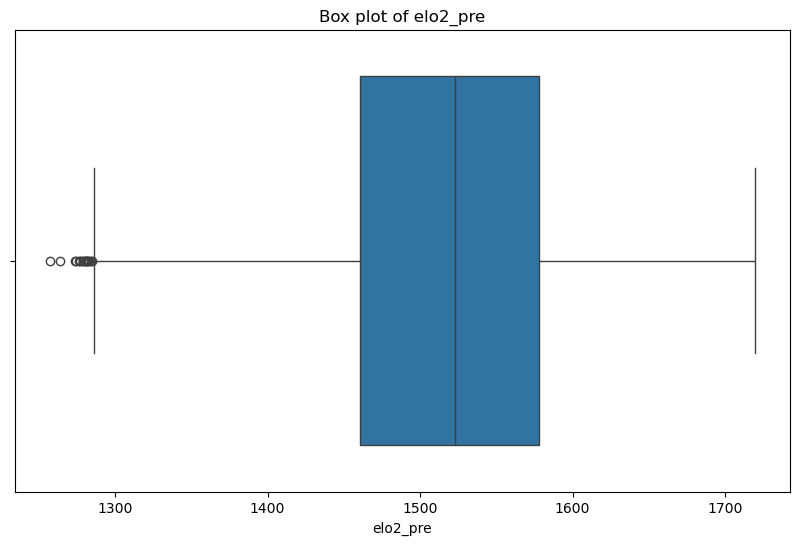

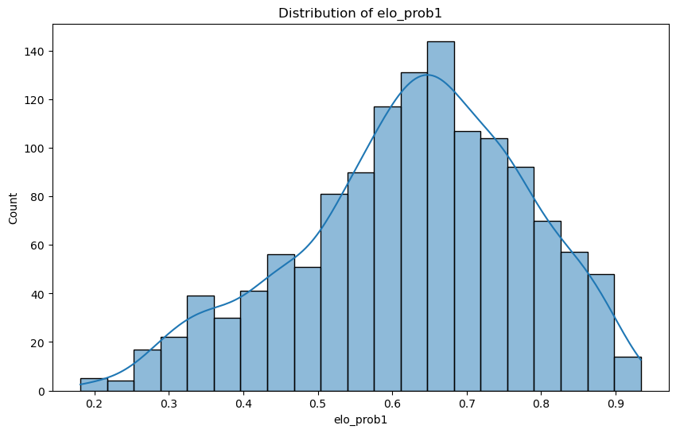

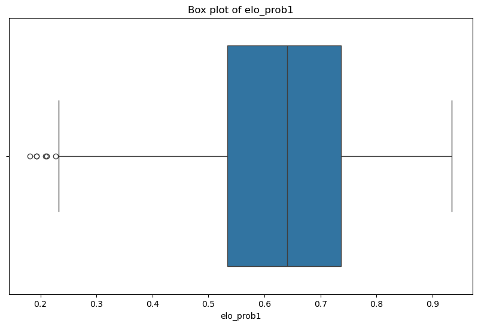

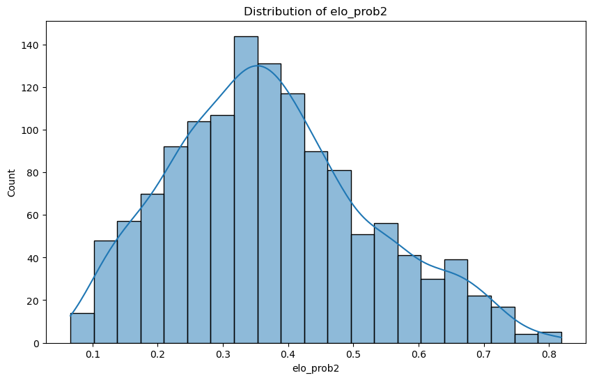

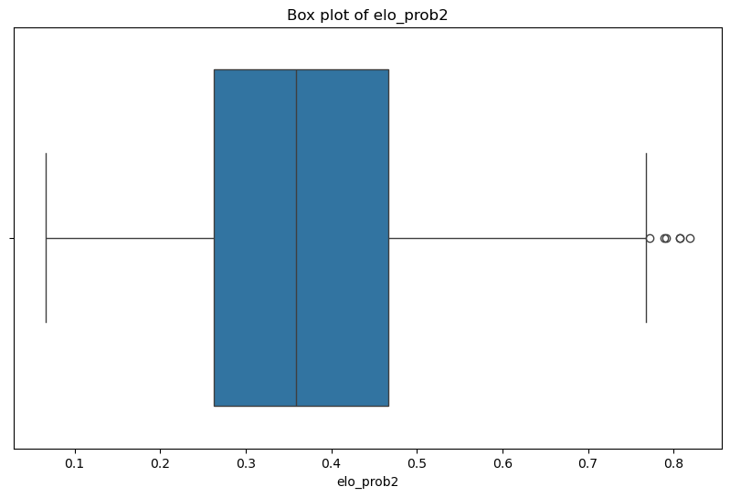

[22 more figures not shown]

```python
statistical_summary = data_cleaned.describe()
print(statistical_summary)
for column in quantitative_columns:
    plt.figure(figsize=(10, 6))
    sns.histplot(data_cleaned[column], kde=True)
    plt.title(f'Distribution of {column}')
    plt.show()

    plt.figure(figsize=(10, 6))
    sns.boxplot(x=data_cleaned[column])
    plt.title(f'Box plot of {column}')
    plt.show()
```

Correlation Analysis

Next, we will explore the relationships between various quantitative columns in the dataset. Understanding these correlations can provide insights into the underlying patterns and associations between different variables.

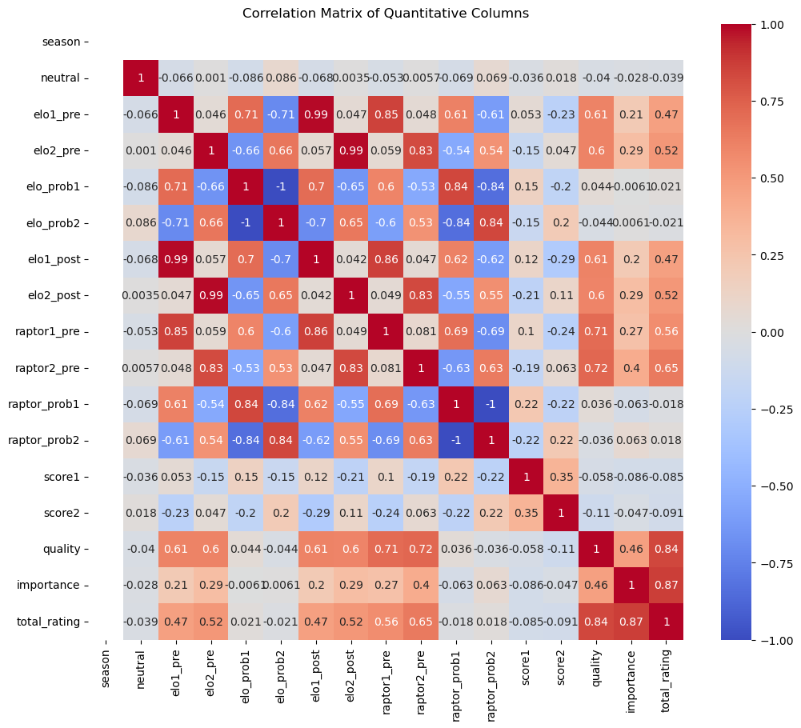

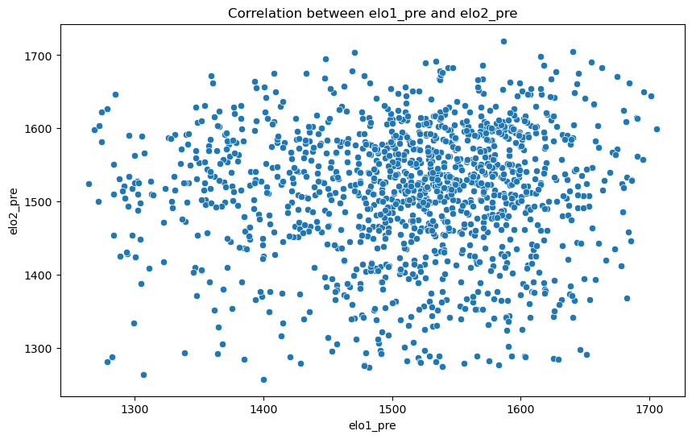

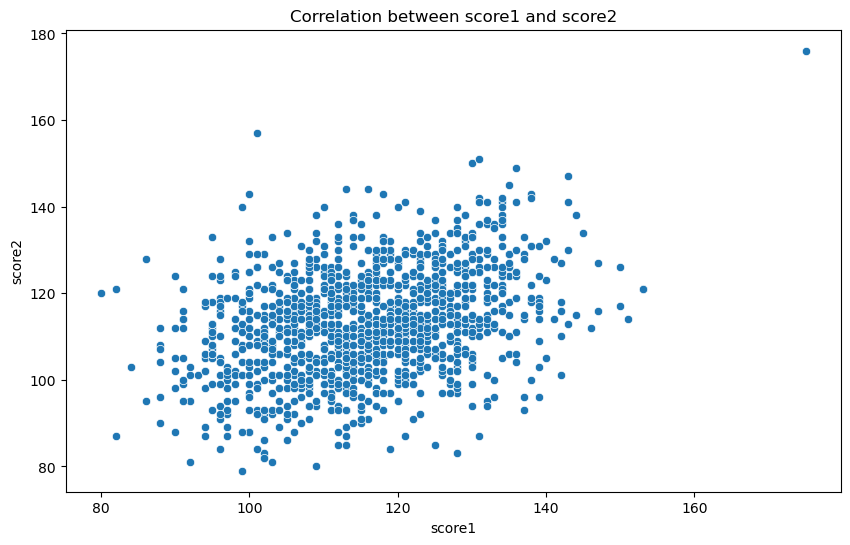

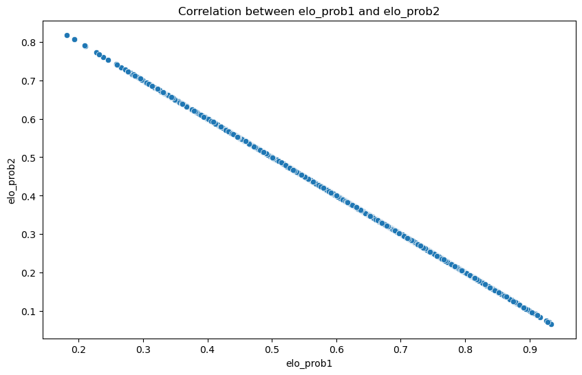

```python
correlation_matrix = data_cleaned[quantitative_columns].corr()

plt.figure(figsize=(12, 10))
sns.heatmap(correlation_matrix, annot=True, cmap='coolwarm')
plt.title('Correlation Matrix of Quantitative Columns')
plt.show()

# Example pairs: ('elo1_pre', 'elo2_pre'), ('score1', 'score2'), ('elo_prob1', 'elo_prob2')
pairs_to_explore = [('elo1_pre', 'elo2_pre'), ('score1', 'score2'), ('elo_prob1', 'elo_prob2')]

for x, y in pairs_to_explore:
    plt.figure(figsize=(10, 6))
    sns.scatterplot(data=data_cleaned, x=x, y=y)
    plt.title(f'Correlation between {x} and {y}')
    plt.xlabel(x)
    plt.ylabel(y)
    plt.show()
```

Discussion

Question 1.

Can the combination of home-court advantage, team ELO ratings, previous game outcomes, and player injury reports predict whether a team will win its next game?

Question 2.

How well can we predict a team's end-of-season ELO rating based on its performance metrics (points per game, rebounds, assists, turnovers) in the first half of the season?